# R Notebook

```r
library(ggplot2)
library(data.table)
library(magrittr)
library(caret)
library(optimx)
```

```r
ex2data1 <- fread("~/Downloads/sort_newest/r/archives_sort_this/Andrew_Machine_Learning_R_optimisation/ex2data1.txt", col.names = c("Exam1", "Exam2", "Label"))
head(ex2data1)
```

| Exam1 | Exam2 | Label |
| --- | --- | --- |
| 34.62366 | 78.02469 | 0 |
| 30.28671 | 43.89500 | 0 |
| 35.84741 | 72.90220 | 0 |
| 60.18260 | 86.30855 | 1 |
| 79.03274 | 75.34438 | 1 |
| 45.08328 | 56.31637 | 0 |

```r
cols <- c("0" = "red", "1" = "blue")

ex2data1 %>%
  ggplot(aes(
    x = Exam1,
    y = Exam2,
    colour = factor(Label)
    )) +
  geom_point(size = 4, shape = 19, alpha = 0.6) +
  scale_colour_manual(values = cols,labels = c("Not admitted", "Admitted"), name = "Admission Status")
```

Logistic Regression hypothesis is defined as:

$$h_\theta(x)=g(\theta^Tx)$$
where function g is the sigmoid function, which is defined as below:
$$g(z)=\frac{1}{1+e^{-z}}$$

```r
my_sigmoid <- function(z) 1/(1+exp(-z))
```

```r
my_sigmoid(c(0, 10^10, -10^10))
```

```
[1] 0.5 1.0 0.0
```

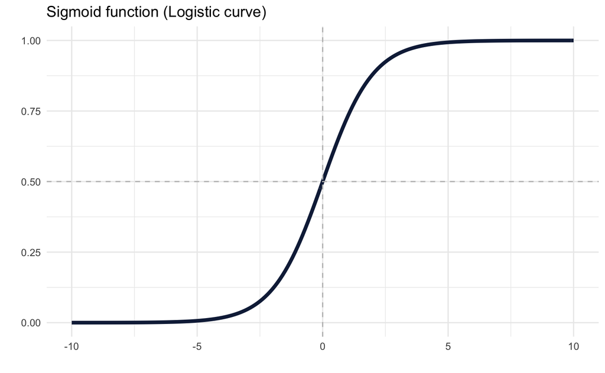

### Cost function and gradient

The cost function in logistic regression is given by:

$$J(\theta)=\frac{1}{m}\sum\limits_{i=1}^{m}[-y^{(i)}log(h_\theta(x^{(i)}))-(1-y^{(i)})log(1-h_\theta(x^{(i)}))]$$

and the gradient of the cost is a vector of the same length as $\theta$ where the $j^{th}$ element (for j = 0, 1, …, n) is defined as follows:

$$\frac{\partial J(\theta)}{\partial \theta_j} = \frac{1}{m}\sum\limits_{i=1}^{m}(h_\theta(x^{(i)})-y^{(i)})x_j^{(i)}$$

Note that while this gradient looks identical to the linear regression gradient, the formula is actually different because linear and logistic regression have different definitions of $h_\theta(x)$.

Add ones for the intercept term:

```r
y <- ex2data1$Label
X <- cbind(1, ex2data1$Exam1, ex2data1$Exam2)
head(X)
```

```r
# Initialize fitting parameters:
initial_theta <- matrix(rep(0, ncol(X)))

# The function below calculates cost.
my_cost <- function(theta, X, y) {
  cost_gradient <- list()
  # cost_and_gradient compute cost and gradient for logistic regression using theta
  h_theta <- my_sigmoid(X %*% theta)
  cost <- 1 / nrow(X) * sum(-y * log(h_theta) - (1 - y) * log(1 - h_theta))
  return(cost)
}

# What is the cost for the initial theta parameters, which are all zeros?
round(my_cost(initial_theta, X, y), 3)
```

The function below calculates gradient.

```r
my_gradient <- function(theta, X, y) {
  h_theta <- my_sigmoid(X %*% theta)

  ## OPTION 1-- looping

  #    gradient=rep(0,ncol(X))
  #      for(j in 1:ncol(X)){
  #       for(i in 1:nrow(X)){
  #    gradient[j]=gradient[j]+1/nrow(X)*(my_sigmoid(X[i,]%*%theta)-y[i])*X[i,j]
  #                   }
  #               }

  # option2-more succint
  gradient <- 1 / nrow(X) * (my_sigmoid(t(theta) %*% t(X)) - t(y)) %*% X
  return(gradient)
}
```

```r
#The gradient for the initial theta parameters, which are all zeros, is shown below
round(my_gradient(initial_theta, X, y),3)
```

[output not shown]

#### General-purpose Optimization in lieu of Gradient Descent

We can use gradient descent to get the optimal theta values but using optimazation libraries converges quicker. So, let’s use the **optim** general-purpose Optimization in R to get the required theta values and the associated cost.

```r
optimized=optim(par=initial_theta,X=X,y=y,fn=my_cost,gr=my_gradient)

names(optimized)
```

```r
cat("The optimized theta values are: ")
round(optimized$par,3)
```

```r
cat('The cost at the final theta values is: ')
round(optimized$value,3)
```

#### Decision Boundary

Now, let’s plot the decision bounday Only 2 points are required to define a line, so let’s choose two endpoints.

```r
plot_x = c(min(ex2data1$Exam1)-2,max(ex2data1$Exam1)+2)

# Calculate the decision boundary line
plot_y = (-1/optimized$par[3])*(optimized$par[2]*plot_x+optimized$par[1])

## Calculate slope and intercept
slope =(plot_y[2]-plot_y[1])/(plot_x[2]-plot_x[1])
intercept=plot_y[2]-slope*plot_x[2]

cols <- c("0" = "red","1" = "blue")
ex2data1%>%ggplot(aes(x=Exam1,y=Exam2,color=factor(Label)))+geom_point(size = 4, shape = 19,alpha=0.6)+
scale_colour_manual(values = cols,labels = c("Not admitted", "Admitted"),name="Admission Status")+
geom_abline(intercept = intercept, slope = slope,col="purple",show.legend=TRUE)
```

```r
round(my_sigmoid(c(1,45,85)%*%optimized$par),3)
```

```r
ex2data1$fitted_result=my_sigmoid(X%*%optimized$par)
ex2data1$fitted_result_label=ifelse(ex2data1$fitted_result>=0.5,1,0)
head(ex2data1)
```

```r
accuracy=sum(ex2data1$Label==ex2data1$fitted_result_label)/(nrow(ex2data1))
accuracy
```

```r
ex2data2 <- fread("ex2data2.txt",col.names=c("Test1","Test2","Label"))
head(ex2data2)
```

```r
cols <- c("0" = "red","1" = "blue")
ex2data2%>%ggplot(aes(x=Test1,y=Test2,color=factor(Label)))+geom_point(size = 4, shape = 19,alpha=0.6)+
scale_colour_manual(values = cols,labels = c("Failed", "Passed"),name="Test Result")
```

```r
new_data=c()

for(i in 1:6){
    for(j in 0:i){
        temp= (ex2data2$Test1)^i+(ex2data2$Test2)^(i-j)
        new_data=cbind(new_data,temp)
    }
}

colnames(new_data)=paste0("V",1:ncol(new_data))
```

```r
head(new_data)
```

```r
y=ex2data2$Label
X=new_data
```

```r
my_cost2=function(theta, X, y,lambda){
    cost_gradient=list()
    # cost_and_gradient compute cost and gradient for logistic regression using theta
    h_theta= my_sigmoid(X%*%theta)
    cost= 1/nrow(X)*sum(-y*log(h_theta)-(1-y)*log(1-h_theta))+lambda/(2*nrow(X))*sum(theta^2)
    return(cost)
}

my_gradient2=function(theta, X, y,lambda){

    h_theta= my_sigmoid(X%*%theta)

    ## OPTION 1-- looping

       gradient=rep(0,ncol(X))

      for(j in 2:ncol(X)){
        for(i in 1:nrow(X)){
        gradient[1]=gradient[1]+1/nrow(X)*(my_sigmoid(X[i,]%*%theta)-y[i])*X[i,1]
        gradient[j]=gradient[j]+1/nrow(X)*(my_sigmoid(X[i,]%*%theta)-y[i])*X[i,j]+lambda/(nrow(X))*theta[j]
                       }
                   }

    # option2-more succint
  # gradient= 1/nrow(X)*(my_sigmoid(t(theta)%*%t(X))-t(y))%*%X+(lambda/(nrow(X)))*c(0,theta[-1])
    return(gradient)
}
```

```r
initial_theta =matrix(rep(0,ncol(X)))

round(my_cost2(initial_theta,X,y,lambda=10),3)
```

```r
optimized=optim(par=initial_theta,X=X,y=y,lambda=1,fn=my_cost2,gr=my_gradient2,method="BFGS")

optimized=(par=initial_theta,X=X,y=y,lambda=1,fn=my_cost2,gr=my_gradient2,method="BFGS")

matrix(as.vector(optimized$par),ncol=9)
```

```r
ex2data2$fitted_result=my_sigmoid(X%*%optimized$par)
```

```r
head(ex2data2)
```

```r
ex2data2$fitted_result_label=ifelse(ex2data2$fitted_result>=0.5,1,0)
head(ex2data2,10)
```

### Evaluating the fit

Let’s calculate `F1 score`, which uses `precision` and `recall`. `Precision` and `rcall` in turn are calculated using `true positive`, `false positive` and `false negative` as defined below. We will also see the model accuracy.

**tp** is the number of true positives: the ground truth label says it’s an anomaly and our algorithm correctly classied it as an anomaly.

**fp** is the number of false positives: the ground truth label says it’s not an anomaly, but our algorithm incorrectly classied it as an anomaly.

**fn** is the number of false negatives: the ground truth label says it’s an anomaly, but our algorithm incorrectly classied it as not being anoma- lous.

The F1 score is computed using precision (prec) and recall (rec):

$$prec = \frac{tp}{tp+fp}$$

$$rec = \frac{tp}{tp+fn}$$

$$F1 = 2.\frac{prec.rec}{prec+rec}$$

```r
tp=sum((ex2data2$Label==1)&(ex2data2$fitted_result_label==1))
fp=sum((ex2data2$Label==0)&(ex2data2$fitted_result_label==1))
prec=tp/(tp+fp)
cat("The precision is:")
round(prec,3)
```

```r
tp=sum((ex2data2$Label==1)&(ex2data2$fitted_result_label==1))
fn=sum((ex2data2$Label==1)&(ex2data2$fitted_result_label==0))
rec=tp/(tp+fn)
cat("The recall is:")
round(rec,3)
```

```r
F1=2*(prec*rec)/(prec+rec)
cat("The F1 score is:")
round(F1,3)
```

```r
accuracy=sum(ex2data2$Label==ex2data2$fitted_result_label)/nrow(ex2data2)

cat("The accuracy is: ")
round(accuracy,3)
```